# Solution 4

**Problem 3**

In this problem, you will consider choosing the tuning parameters for both ridge regession and the lasso, using 10-fold cross-validation. First load “plot-funs.R” and “bstar.Rdata”.

We begin with a true signal `bstar`. Although this is stored as a vector of length p = 2500, `bstar` really represents an image of dimension 50 × 50. You can plot it by calling `plot.image(bstar)`. This image is truly sparse, in the sense that 2084 of its pixels have a value of 0, while 416 pixels have a value of 1. You can think of this image as a toy version of an MRI image that we are interested in collecting.

Suppose that, because of the nature of the machine that collects the MRI image, it takes a long time to measure each pixel value individually, but it’s faster to measure a linear combination of pixel values. We measure n = 1300 linear combinations, with the weights in the linear combination being random, in fact, independently distributed as N(0,1). These measurements are given by the entries of the vector `x %*% bstar` in our R code. Because the machine is not perfect, we don’t get to observe this directly, but we see a noisy version of this. Hence, in terms of our R code, we observe `y = x %*% bstar + rnorm(n,sd=5)`. Now the question is: can we model `y` as a linear combination of the columns of `x` to recover some coefficient vector that is close to `bstar`? Roughly speaking, the answer is yes. Key points here: although the number of measurements n = 1300 is smaller than the dimension p = 2500, the true vector `bstar` is sparse, and the weights in a linear combination are i.i.d normal. This is the idea behind the field of compressed sensing.

The code below is setup to perform ridge regression of `y` on `x`, and the lasso of `y` on `x`, with the tuning parameter for each method selected by cross-validation. You will fill in the missing pieces. It’s helpful to read through the whole file to get a sense of what’s to be accomplished.

**Q3a.** Fill in the missing parts. There are 4 missing parts marked by `# TODO`. When you’re getting started, just to check that things are running without errors, it could be helpful to run the cross-validation loop for only `k=1`. It might also be helpful to read the documentation for the `glmnet()` function, which you will use to perform ridge regression and the lasso.

**Ans:** The missing code snippets are displayed below.

```r
library(glmnet)
```

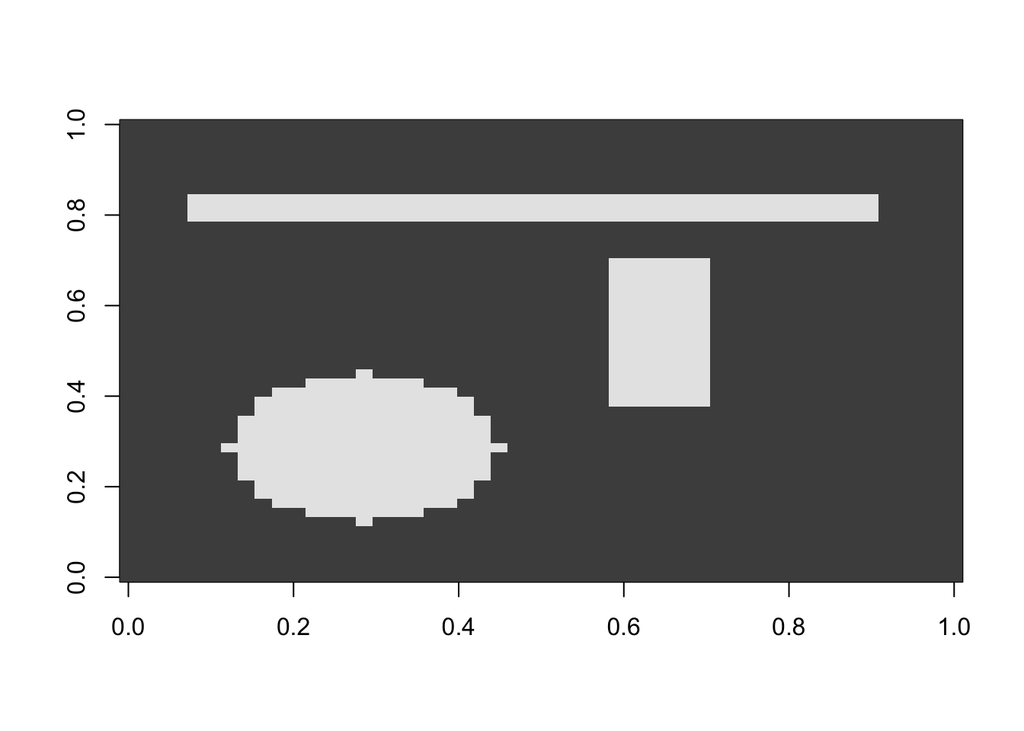

```r
source("plotfuns.R")
load("/Users/shengli/Desktop/bstar.Rdata")

plot.image(bstar)
```

```r
p = length(bstar)
set.seed(0)
n = 1300
x = matrix(rnorm(n*p),nrow=n)
y = x%*%bstar + rnorm(n,sd=5)

K = 10
d = ceiling(n/K)
set.seed(0)
i.mix = sample(1:n)
folds = vector(mode="list",length=K)
# 1) TODO
# Here you need to divide up i.mix into K equal size chunks,
# and then put these chunks in the elements of the folds list,
# folds[[1]], folds[[2]], ..., folds[[K]]
folds = vector(mode="list",length=K)
for (k in 1:(K-1)) {
  folds[[k]] = i.mix[((k-1)*d+1):(k*d)]
}
folds[[K]] = i.mix[((K-1)*d+1):n]

# Tuning parameter values for lasso, and ridge regression
lam.las = c(seq(1e-3,0.1,length=100),seq(0.12,2.5,length=100))
lam.rid = lam.las*1000

nlam = length(lam.las)
# These two matrices store the prediction errors for each
# observation (along the rows), when we fit the model using
# each value of the tuning parameter (along the columns)
e.rid = matrix(0,n,nlam)
e.las = matrix(0,n,nlam)

for (k in 1:K) {
    cat("Fold",k,"\n")

    i.tr = unlist(folds[-k])
    i.val = folds[[k]]

    x.tr = x[i.tr,]   # training predictors
    y.tr = y[i.tr]    # training responses
    x.val = x[i.val,] # validation predictors
    y.val = y[i.val]  # validation responses

    # 2) TODO
    # Now use the function glmnet on the training data to get the
    # ridge regression solutions at all tuning parameter values in
    # lam.rid, and the lasso solutions at all tuning parameter
    # values in lam.las
    #a.rid = glmnet() # for the ridge regression solutions, use alpha=0
    #a.las = glmnet() # for the lasso solutions, use alpha=1
    a.rid = glmnet(x.tr,y.tr,lambda=lam.rid,alpha=0)
    a.las = glmnet(x.tr,y.tr,lambda=lam.las,alpha=1)

    # Here we're actually going to reverse the column order of the
    # a.rid$beta and a.las$beta matrices, because we want their columns
    # to correspond to increasing lambda values (glmnet's default makes
    # it so that these are actually in decreasing lambda order), i.e.,
    # in the same order as our lam.rid and lam.las vectors
    rid.beta = as.matrix(a.rid$beta[,nlam:1])
    las.beta = as.matrix(a.las$beta[,nlam:1])

    yhat.rid = x.val%*%rid.beta
    yhat.las = x.val%*%las.beta

    e.rid[i.val,] = (yhat.rid-y.val)^2
    e.las[i.val,] = (yhat.las-y.val)^2
}
```

```
## Fold 1
## Fold 2
## Fold 3
## Fold 4
## Fold 5
## Fold 6
## Fold 7
## Fold 8
## Fold 9
## Fold 10
```

```r
# 3) TODO
# Here you need to compute:
# -cv.rid, cv.las: vectors of length nlam, giving the cross-validation
#  errors for ridge regresssion and the lasso, across all values of the
#  tuning parameter
# -se.rid, se.las: vectors of length nlam, giving the standard errors
#  of the cross-validation estimates for ridge regression and the lasso,
#  across all values of the tunining parameter
cv.rid = colMeans(e.rid)
cv.las = colMeans(e.las)

pe.rid = matrix(0,K,nlam)
pe.las = matrix(0,K,nlam)
for (k in 1:K) {
    i.val = folds[[k]]
    pe.rid[k,] = colMeans(e.rid[i.val,])
    pe.las[k,] = colMeans(e.las[i.val,])
}
se.rid = apply(pe.rid,2,sd)/sqrt(K)
se.las = apply(pe.las,2,sd)/sqrt(K)

# Usual rule for choosing lambda
i1.rid = which.min(cv.rid)
i1.las = which.min(cv.las)

# 4) TODO
# One standard error rule for choosing lambda
# Here you need to compute:
# -i2.rid: the index of the lambda value in lam.rid chosen
#  by the one standard error rule
# -i2.las: the index of the lambda value in lam.las chosen
#  by the one standard error rule
i1.rid = which.min(cv.rid)
i2.rid = max(which(cv.rid<=cv.rid[i1.rid]+se.rid[i1.rid]))

i1.las = which.min(cv.las)
i2.las = max(which(cv.las<=cv.las[i1.las]+se.las[i1.las]))
```

**3b.** Plot the cross-validation error curves for each of ridge regression and the lasso. You can do this using the function `plot.cv()`, as demonstrated by the code at the end. For both ridge regression and the lasso, what value of λ is chosen by the usual rule? What value is chosen by the one standard error rule? Which method, ridge regression or the lasso, has a smaller minimum cross-validation error?

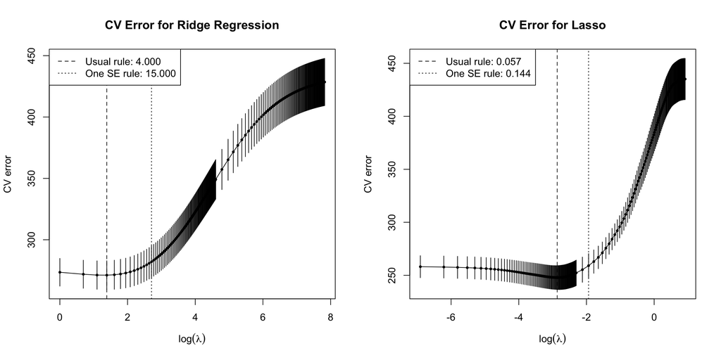

```r
# Figure 1
par(mfrow=c(1,2))
plot.cv(cv.rid,se.rid,lam.rid,i1.rid,i2.rid,
  main='CV Error for Ridge Regression' )
plot.cv(cv.las,se.las,lam.las,i1.las,i2.las,
    main='CV Error for Lasso' )
```

**Q3d.** Look at the squared error between the ridge regression and the lasso coefficients that you computed in (c), for both the estimate chosen by cross-validation and that from the one standard error rule, and the true coefficient vector `bstar`. What has the lowest squared error?

**Ans:** We calculate the following sum of square errors and observe that the lasso using standard cross validation results in the smallest square error.

```r
sum((bstar-rid.beta[,i1.rid])^2)
```

```
## [1] 243.6414
```

```r
sum((bstar-rid.beta[,i2.rid])^2)
```

```
## [1] 258.3403
```

```r
sum((bstar-las.beta[,i1.las])^2)
```

```
## [1] 211.8215
```

```r
sum((bstar-las.beta[,i2.las])^2)
```

```
## [1] 223.568
```